# Mixed Effects Models

Eva Freyhult

NBIS, SciLifeLab

September 9, 2026

## Introduction to mixed models

Grouped observations are very common in the life sciences:

- **Repeated measures**: multiple measurements from the same subject
- **Longitudinal studies**: repeated observations over time
- **Experimental batches**: measurements from different labs, hospitals, plates, or regions
- **Nested designs**: e.g. mice within cages within labs
- **Crossed designs**: e.g. measurements involving both lab and technician

Ordinary linear regression assumes that observations are **independent**. When observations are grouped, this assumption is often violated.

## Simple linear regression

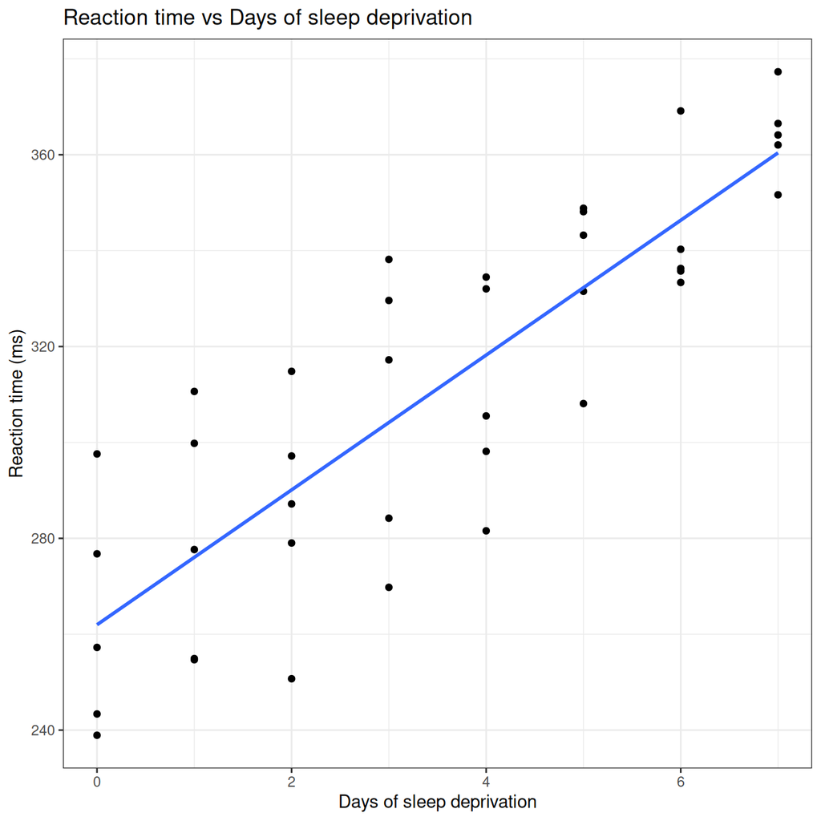

$$y_i = \beta_0 + \beta_1 x_i + \varepsilon_i$$

#### Assumptions

- **Linearity**: The relationship between x and y is linear
- **Independence**: Observations are independent
- **Homoscedasticity**: Constant variance of residuals
- **Normality**: Residuals are normally distributed

The key assumption for grouped data is often **independence**.

## Example: Age and plasma concentration

Is there an association between age and plasma concentration?

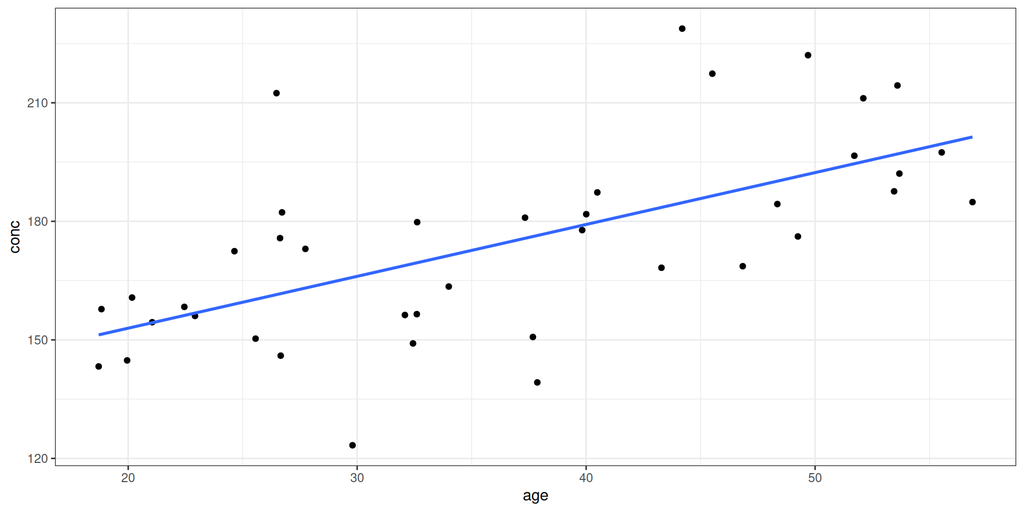

## Example: Age and plasma concentration

```r
m0 <- lm(conc ~ age, data = df)
summary(m0)
```

```
Call:
lm(formula = conc ~ age, data = df)

Residuals:
    Min      1Q  Median      3Q     Max
-42.492 -12.643  -0.968   9.998  50.981

Coefficients:
            Estimate Std. Error t value Pr(>|t|)
(Intercept) 126.7136    10.0424  12.618 3.68e-15 ***
age           1.3124     0.2619   5.011 1.28e-05 ***
---
Signif. codes:  0 '***' 0.001 '**' 0.01 '*' 0.05 '.' 0.1 ' ' 1

Residual standard error: 19.55 on 38 degrees of freedom
Multiple R-squared:  0.3979,    Adjusted R-squared:  0.3821
F-statistic: 25.11 on 1 and 38 DF,  p-value: 1.282e-05
```

## Example: Age and plasma concentration

Are the assumptions fulfilled?

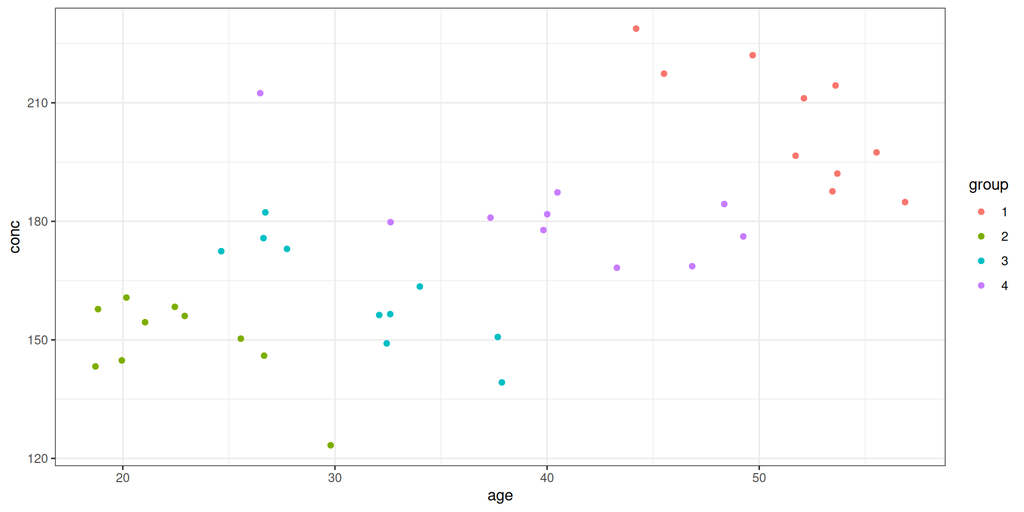

## Group as fixed effect

```r
m1 <- lm(conc ~ age + group, data = df)
summary(m1)
```

```
Call:
lm(formula = conc ~ age + group, data = df)

Residuals:
    Min      1Q  Median      3Q     Max
-16.849  -8.185   0.786   6.618  17.656

Coefficients:
             Estimate Std. Error t value Pr(>|t|)
(Intercept)  303.4541    15.9759  18.994  < 2e-16 ***
age           -1.9022     0.3042  -6.254 3.58e-07 ***
group2      -110.9344     9.7480 -11.380 2.59e-13 ***
group3       -82.1424     7.4540 -11.020 6.29e-13 ***
group4       -44.7618     5.3530  -8.362 7.33e-10 ***
---
Signif. codes:  0 '***' 0.001 '**' 0.01 '*' 0.05 '.' 0.1 ' ' 1

Residual standard error: 9.24 on 35 degrees of freedom
Multiple R-squared:  0.8762,    Adjusted R-squared:  0.862
F-statistic: 61.92 on 4 and 35 DF,  p-value: 2.173e-15
```

## Example: Age and plasma concentration

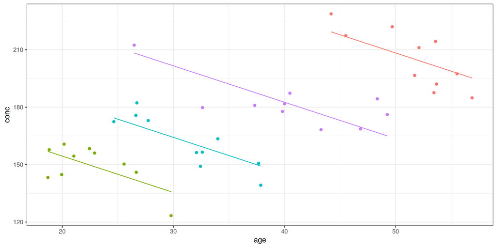

## Linear mixed models

A linear mixed model accounts for the grouping structure by including **random effects**.

Ignoring the grouping structure can lead to:

- Misleading conclusions
- Incorrect standard errors
- Inflated type I error rates

## Fixed effects and random effects

**Fixed effects**

- population-level effects
- estimated explicitly
- typically the main effects of interest

**Random effects**

- account for variation between groups
- assume group effects come from a distribution
- usually summarized by variance components rather than individual parameters

For grouped data:

- **Fixed group effect**: estimate each group separately
- **Random group effect**: model between-group variability

## Grouping structure

The grouping structure can be cohorts, batches, subjects, schools, hospitals, doctors, cages, or labs.

It should be determined from the **study design** and not inferred only from the data.

Note: the grouping variable is categorical.

Note 2: Very few groups makes random-effects estimation unstable.

## Model with fixed and random effects

Once the grouping is decided, we can decide what effects are fixed and what effects are random.

The effects can be:

- Intercept
- Slope
- Interaction

## Model with fixed and random effects

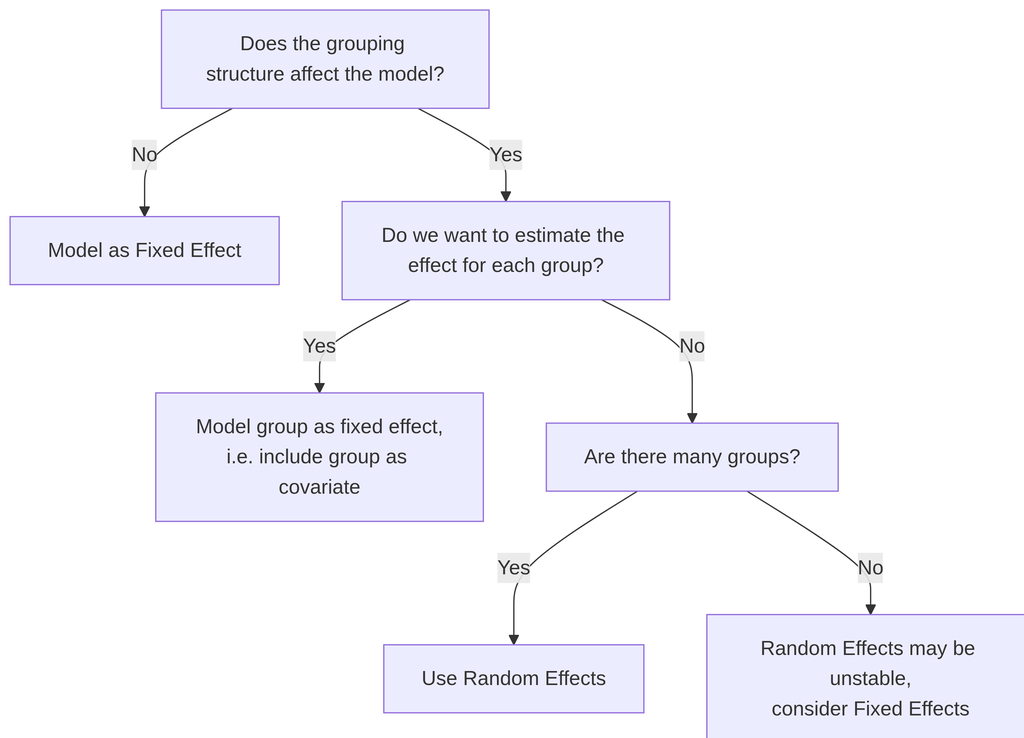

## Example: Age and plasma concentration

We believe that:

- the effect of age on concentration is the same across groups, hence **fixed**
- the intercept (baseline concentration) varies between groups

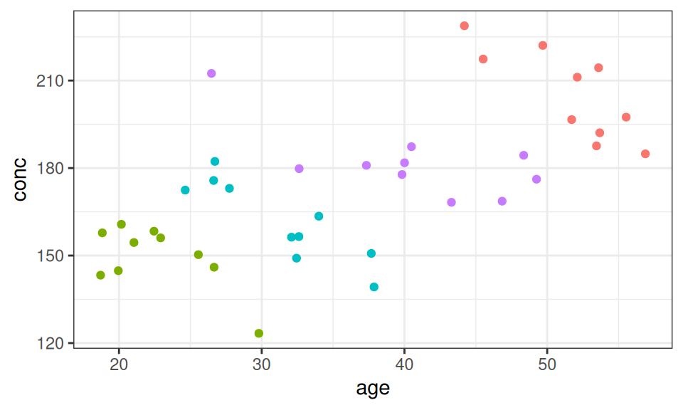

## Random intercept model

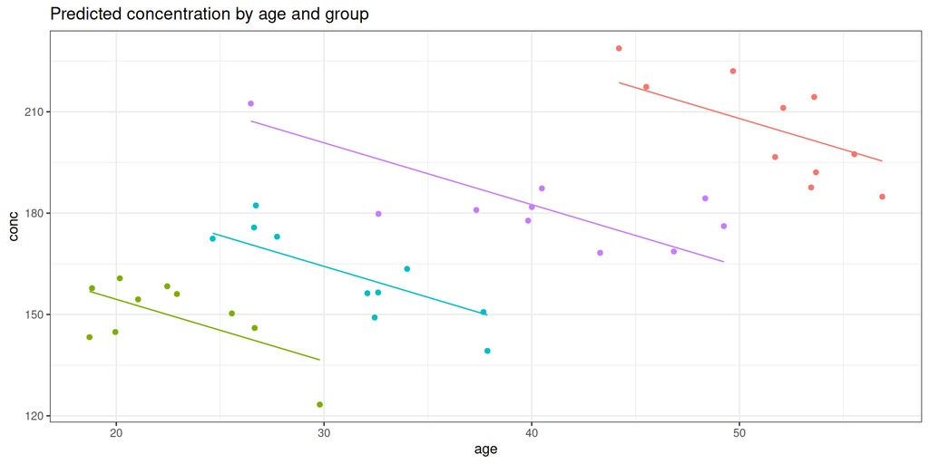

## Random intercept model

$$y_{ij} = \beta_0 + \beta_1 x_{ij} + b_{0i} + \varepsilon_{ij}$$

- $y_{ij}$: outcome, dependent variable (concentration)
- $\beta_0, \beta_1$: fixed effects (intercept and slope)
- $b_{0i}$: random intercept for group $i$
- $b_{0i} \sim N(0, \sigma_{b_0}^2)$, where $\sigma_{b_0}$ is the standard deviation of the random intercept
- $\varepsilon_{ij}$: residual error

## Mixed model in R

```r
mm <- lmer(conc ~ age + (1 | group), data = df)
summary(mm)
```

```
Linear mixed model fit by REML ['lmerMod']
Formula: conc ~ age + (1 | group)
   Data: df

REML criterion at convergence: 304.1

Scaled residuals:
     Min       1Q   Median       3Q      Max
-1.75481 -0.89181  0.09125  0.70848  1.85339

Random effects:
 Groups   Name        Variance Std.Dev.
 group    (Intercept) 2224.44  47.164
 Residual               85.47   9.245
Number of obs: 40, groups:  group, 4

Fixed effects:
            Estimate Std. Error t value
(Intercept) 241.3334    26.0615   9.260
age          -1.8293     0.3014  -6.068

Correlation of Fixed Effects:
    (Intr)
age -0.422
```

- `age`: fixed effect
- `(1 | group)`: random intercept for group

## Interpreting the model

The output contains:

- **Fixed effects**: the overall association between age and concentration
- **Random effects**: variability in intercepts across groups
- **Residual variance**: remaining within-group variation

```r
var_components <- as.data.frame(VarCorr(mm))
icc <- var_components$vcov[1] / sum(var_components$vcov)
icc
```

```
[1] 0.9629976
```

The intra-class correlation coefficient (ICC) is the proportion of total variance attributable to the grouping structure.

## Predicting fixed and random effects

Fixed effects can be extracted using `fixef()`.

```r
fixef(mm)
```

```
(Intercept)         age
 241.333393   -1.829255
```

The random effects can be predicted using `ranef()`.

```r
ranef(mm)
```

```
$group
  (Intercept)
1    58.13116
2   -50.26973
3   -22.21498
4    14.35354

with conditional variances for "group"
```

The fixed effects give the overall mean structure, and the random effects are deviations for each group.

## Random slope

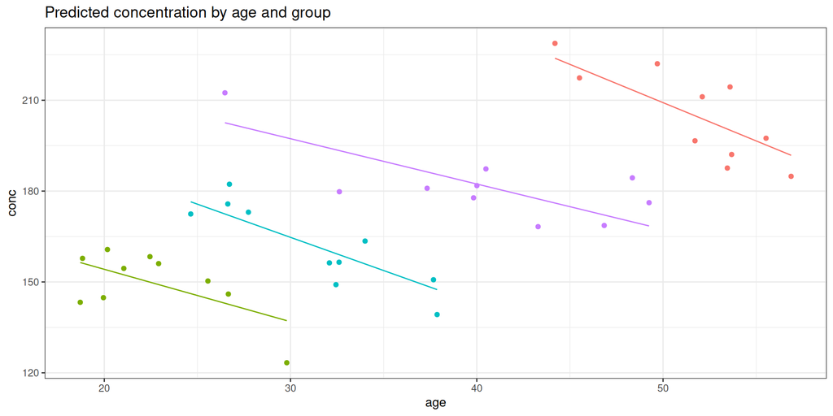

## Random slope

If you believe that the slope also varies between groups, include random slope for age in addition to random intercept.

$$y_{ij} = \beta_0 + \beta_1 x_{ij} + b_{0i} + b_{1i} x_{ij} + \varepsilon_{ij} = \\
\beta_0 + b_{0i} + (\beta_1 + b_{1i}) x_{ij} + \varepsilon_{ij}$$

- $y_{ij}$: outcome, dependent variable (concentration)
- $\beta_0, \beta_1$: fixed effects (intercept and slope)
- $b_{0i}$: random intercept per group (for group $i$)
- $b_{0i} \sim N(0, \sigma_{b_0}^2)$, where $\sigma_{b_0}$ is the standard deviation of the random intercept
- $b_{1i} \sim N(0, \sigma_{b_1}^2)$, where $\sigma_{b_1}$ is the standard deviation of the random slope
- $\varepsilon_{ij}$: residual error

## Random slope in R

```r
mm2 <- lmer(conc ~ age + (1 + age | group), data = df)
summary(mm2)
```

```
Linear mixed model fit by REML ['lmerMod']
Formula: conc ~ age + (1 + age | group)
   Data: df

REML criterion at convergence: 302.9

Scaled residuals:
    Min      1Q  Median      3Q     Max
-1.5822 -0.8157  0.2107  0.7805  1.6553

Random effects:
 Groups   Name        Variance  Std.Dev. Corr
 group    (Intercept) 4113.8342 64.1392
          age            0.3925  0.6265  -0.67
 Residual               77.1173  8.7816
Number of obs: 40, groups:  group, 4

Fixed effects:
            Estimate Std. Error t value
(Intercept) 249.2426    34.0378   7.323
age          -1.9862     0.4373  -4.542

Correlation of Fixed Effects:
    (Intr)
age -0.682
```

## More complex grouping structures

So far we have considered one grouping factor.

In real studies, grouping structures can be more complex and involve more than one level.

## Nested and crossed designs

**Nested**: lower-level units are associated with only **one** higher-level unit

**Crossed**: lower-level units are associated with **multiple** higher-level units

## Nested designs

In a nested design, observations are organized hierarchically. For example, patients within clinics and clinics within regions.

```
graph TD
    A[Region 1]
    A --> B[Clinic 1]
    A --> C[Clinic 2]
    A --> D[Clinic 3]

    B -.-> M1[Patient 1]
    B -.-> N2[Patient 2]
    B -.-> O3[Patient 3]

    C -.-> P4[Patient 4]
    C -.-> Q5[Patient 5]
    C -.-> R6[Patient 6]

    D -.-> S7[Patient 7]
    D -.-> T8[Patient 8]
    D -.-> U9[Patient 9]

    classDef region fill:#f9f,stroke:#333,stroke-width:2px;
    classDef clinic fill:#ccf,stroke:#333,stroke-width:2px;
    classDef patient fill:#cff,stroke:#333,stroke-width:1px;

    class A region;
    class B,C,D clinic;
    class M1,N2,O3,P4,Q5,R6,S7,T8,U9 patient;

    linkStyle default stroke-width:4px;
```

```
graph TD
    E[Region 2]
    E --> F[Clinic 4]
    E --> G[Clinic 5]
    E --> H[Clinic 6]

    F -.-> V10[Patient 10]
    F -.-> W11[Patient 11]
    F -.-> X12[Patient 12]

    G -.-> Y13[Patient 13]
    G -.-> Z14[Patient 14]
    G -.-> A15[Patient 15]

    H -.-> B16[Patient 16]
    H -.-> C17[Patient 17]
    H -.-> D18[Patient 18]

    I[Region 3]
    I --> J[Clinic 7]
    I --> K[Clinic 8]
    I --> L[Clinic 9]

    J -.-> E19[Patient 19]
    J -.-> F20[Patient 20]
    J -.-> G21[Patient 21]

    K -.-> H22[Patient 22]
    K -.-> I23[Patient 23]
    K -.-> J24[Patient 24]

    L -.-> K25[Patient 25]
    L -.-> L26[Patient 26]
    L -.-> M27[Patient 27]

    classDef region fill:#f9f,stroke:#333,stroke-width:2px;
    classDef clinic fill:#ccf,stroke:#333,stroke-width:2px;
    classDef patient fill:#cff,stroke:#333,stroke-width:1px;

    class E,I region;
    class F,G,H,J,K,L clinic;
    class V10,W11,X12,Y13,Z14,A15,B16,C17,D18,E19,F20,G21,H22,I23,J24,K25,L26,M27 patient;

    linkStyle default stroke-width:4px;
```

## Nested model

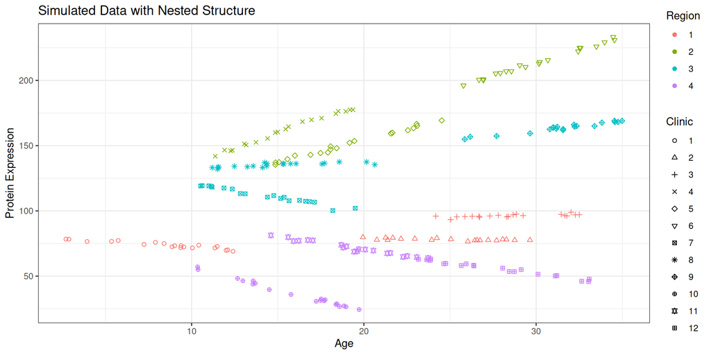

## Nested models in R

In R and `lme4`, random effects for nested groupings can be included. Random intercepts for both regions and clinics nested within regions can be included as follows;

```r
nested_model <- lmer(y ~ x + (1 | region/clinic),
                     data = data_int_nested)
```

`(1 | region/clinic)` specifies random intercepts for clinics nested within regions.

Note that

`(1 | region/clinic)` is identical to

`(1 | region) + (1 | region:clinic)`

A third way to implement the same model is to make the nesting implicit by coding the lower levels (here clinics) uniquely, so that a clinic name only exists in one region. With such a naming scheme, we can use the notation `(1|region) + (1|clinic)`.

## Nested models in R

```r
nested_model <- lmer(y ~ x + (1 | region/clinic), data = data_int_nested)
summary(nested_model)
```

```
Linear mixed model fit by REML ['lmerMod']
Formula: y ~ x + (1 | region/clinic)
   Data: data_int_nested

REML criterion at convergence: 1689.8

Scaled residuals:
     Min       1Q   Median       3Q      Max
-2.57686 -0.54281 -0.05204  0.44631  3.07737

Random effects:
 Groups        Name        Variance Std.Dev.
 clinic:region (Intercept)  473.98  21.771
 region        (Intercept) 2765.06  52.584
 Residual                    50.84   7.131
Number of obs: 240, groups:  clinic:region, 12; region, 4

Fixed effects:
            Estimate Std. Error t value
(Intercept) 105.7145    27.2460   3.880
x             0.3223     0.1617   1.993

Correlation of Fixed Effects:
  (Intr)
x -0.124
```

## Crossed designs

In a crossed design, an observation is associated with multiple groupings. For example, patients may be treated by different doctors at several clinics.

```
graph TD

    A[Clinic 1]
    E[Clinic 2]
    I[Clinic 3]

    B[Doctor 1]
    C[Doctor 2]
    D[Doctor 3]

    M1[Patient 1]
    M2[Patient 2]
    M3[Patient 3]
    M4[Patient 4]
    M5[Patient 5]


    A -.-> B
    A -.-> C
    A -.-> D
    E -.-> B
    E -.-> C
    E -.-> D
    I -.-> B
    I -.-> C
    I -.-> D

    %% Patients connected to clinics to show they can come from any clinic, implying crossed with regions
    B --> M1
    B --> M2
    B --> M3
    B --> M4
    B --> M5

    C --> M1
    C --> M2
    C --> M3
    C --> M4
    C --> M5

    D --> M1
    D --> M2
    D --> M3
    D --> M4
    D --> M5

    %% Additional patient connections omitted for brevity

    classDef region fill:#f9f,stroke:#333,stroke-width:2px;
    classDef clinic fill:#ccf,stroke:#333,stroke-width:2px;
    classDef patient fill:#cff,stroke:#333,stroke-width:1px;

    class A,E,I region;
    class B,C,D,F,G,H,J,K,L clinic;
    class M1,M2,M3,M4,M5 patient;

    linkStyle default stroke-width:4px;
```

## Crossed model in R

A crossed design can be coded as:

`y ~ x + (1 | clinic) + (1 | doctor)`

## Model selection in mixed models

Mixed models can become complex and model selection can help us choose a suitable model.

Likelihood ratio tests (LRT) can be used to compare nested models

We can compare:

- different **random-effects** structures
- different **fixed-effects** structures

## What is LRT?

The likelihood is a measure of how well a model explains the data.

The likelihood ratio test compares the likelihoods of two models: the **null** model, which is a simpler model, and the **alternative**, more complex, model.

$$\lambda = - 2\ln{ \frac{L(restricted\,model)}{L(full\, model)}}$$

The test statistic is approximately $\chi^2$-distributed with degrees of freedom equal to the difference in the number of parameters between the two models.

A significant difference in likelihoods suggests that the more complex model explains the data better than the simpler model.

For mixed models, we can use the `anova()` function to perform LRT. We will start by testing the random effects structure, without change of fixed effects. Then we will test the fixed effects structure, keeping the random effects fixed.

## ML and REML

Mixed models can be fitted using:

- **Maximum Likelihood (ML)**
- **Restricted Maximum Likelihood (REML)**

Use:

- **REML** when comparing random-effects structures with the same fixed effects (`refit = FALSE`)
- **ML** when comparing fixed-effects structures (`refit = TRUE`)
- **REML** for the final model

## Random effects comparison

Sleep study data: random intercept

```r
sleepall <- sleepstudy |> filter(Days>=2) |> mutate(Days=Days-2)
m1 <- lmer(Reaction ~ Days + (1 | Subject), data = sleepall)
summary(m1)
```

```
Linear mixed model fit by REML ['lmerMod']
Formula: Reaction ~ Days + (1 | Subject)
   Data: sleepall

REML criterion at convergence: 1430

Scaled residuals:
    Min      1Q  Median      3Q     Max
-3.6261 -0.4450  0.0474  0.5199  4.1378

Random effects:
 Groups   Name        Variance Std.Dev.
 Subject  (Intercept) 1746.9   41.80
 Residual              913.1   30.22
Number of obs: 144, groups:  Subject, 18

Fixed effects:
            Estimate Std. Error t value
(Intercept)  267.967     10.871   24.65
Days          11.435      1.099   10.40

Correlation of Fixed Effects:
     (Intr)
Days -0.354
```

## Random effects comparison

Sleep study data: random intercept and random slope for Days.

```r
m2 <- lmer(Reaction ~ Days + (1 + Days | Subject), data = sleepall)
summary(m2)
```

```
Linear mixed model fit by REML ['lmerMod']
Formula: Reaction ~ Days + (1 + Days | Subject)
   Data: sleepall

REML criterion at convergence: 1404.1

Scaled residuals:
    Min      1Q  Median      3Q     Max
-4.0157 -0.3541  0.0069  0.4681  5.0732

Random effects:
 Groups   Name        Variance Std.Dev. Corr
 Subject  (Intercept) 958.35   30.957
          Days         45.78    6.766   0.18
 Residual             651.60   25.526
Number of obs: 144, groups:  Subject, 18

Fixed effects:
            Estimate Std. Error t value
(Intercept)  267.967      8.266  32.418
Days          11.435      1.845   6.197

Correlation of Fixed Effects:
     (Intr)
Days -0.062
```

## Random effects comparison

Compare the two models using a likelihood ratio test.

```r
anova(m1, m2, refit = FALSE)
```

```
Data: sleepall
Models:
m1: Reaction ~ Days + (1 | Subject)
m2: Reaction ~ Days + (1 + Days | Subject)
   npar    AIC    BIC  logLik -2*log(L)  Chisq Df Pr(>Chisq)
m1    4 1438.0 1449.9 -715.01    1430.0
m2    6 1416.1 1433.9 -702.05    1404.1 25.926  2  2.346e-06 ***
---
Signif. codes:  0 '***' 0.001 '**' 0.01 '*' 0.05 '.' 0.1 ' ' 1
```

## Fixed effects comparison

We can also compare models with different fixed effects structures. For example, we can compare a model with a fixed effect of `Days` to a model with a fixed effect of `Days` and `Sex`.

```r
m2 <- lmer(Reaction ~ Days + (1 + Days | Subject), data = sleepall)
m3 <- lmer(Reaction ~ Days + sex + (1 + Days | Subject), data = sleepall)
anova(m2, m3, refit=TRUE)
```

```
Data: sleepall
Models:
m2: Reaction ~ Days + (1 + Days | Subject)
m3: Reaction ~ Days + sex + (1 + Days | Subject)
   npar    AIC    BIC  logLik -2*log(L)  Chisq Df Pr(>Chisq)
m2    6 1425.2 1443.0 -706.58    1413.2
m3    7 1422.3 1443.1 -704.14    1408.3 4.8826  1    0.02713 *
---
Signif. codes:  0 '***' 0.001 '**' 0.01 '*' 0.05 '.' 0.1 ' ' 1
```

## P-value calculations

As you have noticed, `lme4` does not report p-values for the fixed effects.

In linear regression, p-values are calculated based on the t-distribution of the estimated coefficients. The calculation of denominator degrees of freedom is straightforward since all observations are independent.

In mixed models, p-values are more complicated because the denominator degrees of freedom are not straightforward.

Approximation methods such as **Satterthwaite** and **Kenward-Roger** can be used.

## `lmerTest`

```r
library(lmerTest)
mm <- lmer(conc ~ age + (1 | group), data = df)
summary(mm)
```

```
Linear mixed model fit by REML. t-tests use Satterthwaite's method [
lmerModLmerTest]
Formula: conc ~ age + (1 | group)
   Data: df

REML criterion at convergence: 304.1

Scaled residuals:
     Min       1Q   Median       3Q      Max
-1.75481 -0.89181  0.09125  0.70848  1.85339

Random effects:
 Groups   Name        Variance Std.Dev.
 group    (Intercept) 2224.44  47.164
 Residual               85.47   9.245
Number of obs: 40, groups:  group, 4

Fixed effects:
            Estimate Std. Error       df t value Pr(>|t|)
(Intercept) 241.3334    26.0615   4.2275   9.260  0.00058 ***
age          -1.8293     0.3014  36.1653  -6.068 5.54e-07 ***
---
Signif. codes:  0 '***' 0.001 '**' 0.01 '*' 0.05 '.' 0.1 ' ' 1

Correlation of Fixed Effects:
    (Intr)
age -0.422
```

## `lmerTest`

```r
mmsleep <- lmer(Reaction ~ Days + (1 + Days | Subject), data = sleepall)
summary(mmsleep)
```

```
Linear mixed model fit by REML. t-tests use Satterthwaite's method [
lmerModLmerTest]
Formula: Reaction ~ Days + (1 + Days | Subject)
   Data: sleepall

REML criterion at convergence: 1404.1

Scaled residuals:
    Min      1Q  Median      3Q     Max
-4.0157 -0.3541  0.0069  0.4681  5.0732

Random effects:
 Groups   Name        Variance Std.Dev. Corr
 Subject  (Intercept) 958.35   30.957
          Days         45.78    6.766   0.18
 Residual             651.60   25.526
Number of obs: 144, groups:  Subject, 18

Fixed effects:
            Estimate Std. Error      df t value Pr(>|t|)
(Intercept)  267.967      8.266  17.000  32.418  < 2e-16 ***
Days          11.435      1.845  16.999   6.197 9.75e-06 ***
---
Signif. codes:  0 '***' 0.001 '**' 0.01 '*' 0.05 '.' 0.1 ' ' 1

Correlation of Fixed Effects:
     (Intr)
Days -0.062
```

# Summary

- Mixed models are used when observations are grouped and therefore not independent
- Fixed effects describe population-level effects
- Random effects account for variation between groups
- Random intercepts allow different baselines
- Random slopes allow different responses to a predictor
- Grouping structures can be nested or crossed
- Model comparison should distinguish between fixed and random parts
- Use REML for the final model, and ML when comparing fixed effects
- Approximate p-values can be obtained using `lmerTest` ```